# Text Analysis - Quiz 1

Submitted by Zsófia Rebeka Katona

The objective of this quiz was to identify the speech most closely resembling the initial speech given by a selected Senator. I conducted an analysis to determine the key attributes of the most similar speech. Moreover, I investigated if the speeches were becoming more similar or dissimilar over time. Additionally, I explored different measures of similarity.

```python
# Importing required libraries
import glob
import os
import re
import string
import nltk
import time
import requests
import pandas as pd
import numpy as np
import seaborn as sns
import matplotlib.pyplot as plt

from sklearn.feature_extraction.text import CountVectorizer
from sklearn.feature_extraction.text import TfidfVectorizer
from sklearn.feature_extraction.text import ENGLISH_STOP_WORDS
from nltk.stem import PorterStemmer, SnowballStemmer, WordNetLemmatizer ,LancasterStemmer
from nltk.corpus import stopwords
from nltk.tokenize import word_tokenize
from sklearn.metrics.pairwise import cosine_similarity
```

```python
# Importing Mr. Allard's speeches
url = "https://raw.githubusercontent.com/ariedamuco/Python-Programming-and-Text-Analysis/master/Inputs/105-extracted-date/105-allard-co.txt"

# Converting the droplist into a list
response = requests.get(url)
content = response.text

# Extracting strings between <DOC> tags using regex
speech_list = re.findall(r'<DOC>(.*?)</DOC>', content, re.DOTALL)

# Initializing a list to store the extracted strings
extracted_strings = []

# Iterating through each speech in the speech_list
for speech in speech_list:
    # Extracting strings between <TEXT> tags
    strings_between_text_tags = re.findall(r'<TEXT>(.*?)</TEXT>', speech, re.DOTALL)

    # Adding the extracted strings to the list
    extracted_strings.extend(strings_between_text_tags)
```

```python
# Defining the stop words from scikit learn's package
stop_words = list(ENGLISH_STOP_WORDS)
```

```python
# Comparing the number of stop_words (before adding the droplist.txt)
len(stop_words)
```

```
318
```

```python
# Defining the preprocess_text function to clean the speeches
def preprocess_texts(texts, stop_words):
    preprocessed_texts = []
    for text in texts:
        # Converting the texts to lowercase
        text_lower = text.lower()

        # Removing punctuation
        text_no_punctuation = text_lower.translate(str.maketrans('', '', string.punctuation))

        # Tokenizing the text into words
        words = text_no_punctuation.split()

        # Removing the scikit stop words
        filtered_words = [word for word in words if word not in stop_words]

        # Joining the filtered words into a string
        preprocessed_text = ' '.join(filtered_words)

        # Appending the preprocessed text to the list
        preprocessed_texts.append(preprocessed_text)

    return preprocessed_texts

# Preprocessing the speeches in extracted_strings
preprocessed_texts = preprocess_texts(extracted_strings, stop_words)
```

```python
# Checking the first text we are comparing the other texts to
preprocessed_texts[0]
```

```
'mr allard mr president rise make remarks concerning auto choice reform act cosponsor legislation auto choice act proposes development fault compensation provide option drivers want pay services want use legislation allow recovery economic losses recovery noneconomic damages like pain suffering choo…
```

```python
# Vectorizing with Tfidf
tfidf_vectorizer = TfidfVectorizer()

# Fitting and transforming the preprocessed documents
tfidf_matrix = tfidf_vectorizer.fit_transform(preprocessed_texts)

# Checking the size of the matrix
tfidf_matrix
```

```
<318x6982 sparse matrix of type '<class 'numpy.float64'>'
	with 27928 stored elements in Compressed Sparse Row format>
```

### *Cosine similarity without stemming and lemmatizing*

```python
# Defining a function to compute the cosine similarity scores in the matrix
def cosine_similarity_comparison(tfidf_matrix):

    # Extracting the TF-IDF vector of the first text
    first_text_tfidf_vector = tfidf_matrix[0]

    # Calculating cosine similarity between the first text and all the other texts
    cosine_similarities = cosine_similarity(first_text_tfidf_vector, tfidf_matrix[1:])

    # Flattening the cosine similarities array
    cosine_similarities_flat = cosine_similarities.flatten()

    return cosine_similarities_flat

# Calculating and printing the cosine similarity scores
cosine_similarities = cosine_similarity_comparison(tfidf_matrix)
print("Cosine similarities:", cosine_similarities)
```

```
Cosine similarities: [0.07376912 0.05844145 0.08537493 0.02249191 0.03391719 0.01877183
 0.00432162 0.02626414 0.01015617 0.0653299  0.00346669 0.07227029
 0.02703412 0.03083688 0.02757296 0.00780261 0.0032214  0.00394405
 0.02886693 0.04670322 0.01349334 0.01183987 0.00574822 0.01854772
 0.00357449 0.00214945 0.0021447  0.01898682 0.05584112 0.01065035
 0.01696702 0.03211537 0.03583341 0.05933693 0.00675506 0.02449995
 0.00630446 0.00136523 0.00625962 0.00243858 0.0064822  0.01157669
 0.00651559 0.01421738 0.01530924 0.00595032 0.02548296 0.01281093
 0.00509436 0.07910021 0.01879936 0.04988937 0.10767867 0.00354333
 0.04706474 0.01412663 0.04052415 0.04375456 0.04973909 0.02403885
 0.03960625 0.03107463 0.04117712 0.02424624 0.03187025 0.01533805
 0.02376005 0.02899033 0.01730908 0.00577427 0.00593605 0.0072518
 0.00371234 0.0092975  0.01533805 0.01819586 0.00675506 0.0145782
 0.03382248 0.02303084 0.03114857 0.02638301 0.00818995 0.0340577
 0.02338171 0.0022087  0.02370749 0.0103141  0.00996945 0.10722187
 0.03514609 0.00780261 0.04824476 0.001846   0.06503088 0.00934803
 0.00648986 0.0163238  0.00665487 0.05249429 0.00450334 0.01489745
 0.00361154 0.00419824 0.00646406 0.00747709 0.0064822  0.07515462
 0.04971197 0.01234071 0.00675506 0.01735638 0.02628963 0.04785042
 0.01845218 0.12702169 0.00817978 0.0092889  0.02580263 0.01438832
 0.05236007 0.05410516 0.01767455 0.03135544 0.01035333 0.00962794
 0.01348251 0.02197983 0.01492908 0.02806856 0.03480383 0.04967796
 0.00765249 0.01416551 0.03834579 0.01264849 0.00990885 0.03763523
 0.02230639 0.05723307 0.02918926 0.00583256 0.00762325 0.04895997
 0.00314545 0.00426293 0.00574822 0.03705152 0.00180482 0.00823844
 0.0064822  0.01977681 0.00128384 0.01821397 0.01077665 0.00783457
 0.00880157 0.01775615 0.08020135 0.00574822 0.01401121 0.01952059
 0.02042911 0.01183249 0.03378984 0.00435254 0.0151101  0.012935
 0.04596304 0.01619947 0.02458168 0.05892991 0.00573012 0.00628908
 0.01138822 0.00502197 0.04846183 0.0675511  0.00184198 0.07618682
 0.00463897 0.02039251 0.03565619 0.01731133 0.00505892 0.00780261
 0.00675506 0.09220629 0.00527712 0.00384635 0.06948188 0.04749737
 0.0732494  0.00428618 0.02169098 0.02409031 0.05013852 0.03145148
 0.00602201 0.01329574 0.06024478 0.01366568 0.02079645 0.02987997
 0.02040047 0.04835541 0.01469788 0.02642091 0.06993882 0.0794594
 0.03381138 0.00675506 0.00780261 0.00191358 0.00355999 0.00461732
 0.00266304 0.00174661 0.0064822  0.09172134 0.00173689 0.04996352
 0.0032214  0.01876612 0.02886191 0.00829196 0.0064822  0.01062396
 0.00263606 0.07244784 0.05929323 0.00863809 0.13880135 0.10471699
 0.00838286 0.0327149  0.00556088 0.00827187 0.01759429 0.02972777
 0.00205437 0.0064822  0.04075183 0.07228309 0.00934513 0.01128096
 0.01187472 0.10022902 0.01244984 0.01151617 0.05152514 0.00842632
 0.0064822  0.05509039 0.06624275 0.11593628 0.04173821 0.0032214
 0.00703894 0.07413097 0.06939271 0.01771729 0.04339723 0.01662453
 0.00675506 0.01186649 0.04179801 0.01821397 0.01973496 0.00188873
 0.00602201 0.00307357 0.05094716 0.00478937 0.00255883 0.00990657
 0.00747709 0.0064822  0.0290858  0.05221335 0.01033578 0.06467282
 0.00172788 0.0048342  0.00423251 0.05584026 0.03460663 0.02506274
 0.00780261 0.00675506 0.00702739 0.03623369 0.00322347 0.04598911
 0.01493194 0.0495155  0.01584135 0.04442182 0.10140917 0.05868986
 0.03228059 0.00675506 0.07294426 0.05908526 0.05682962 0.01951321
 0.02654776 0.03118331 0.01063281 0.00980403 0.03537797 0.03467088
 0.01808373 0.07326464 0.00780261 0.08974417 0.04662347]
```

```python
# Initializing an empty DataFrame to store results
results_df = pd.DataFrame(columns=['Text Index', 'Cosine Similarity'])

# Finding the index of the most similar text and its cosine similarity score
max_similarity_index = cosine_similarities.argmax()
max_similarity_score = cosine_similarities.max()

# Appending the index and the score to the results_df
new_result = pd.DataFrame({'Text Index': [max_similarity_index + 1],  # Adjusting for 0-based indexing
                           'Cosine Similarity': [max_similarity_score]})
results_df = pd.concat([results_df, new_result], ignore_index=True)
```

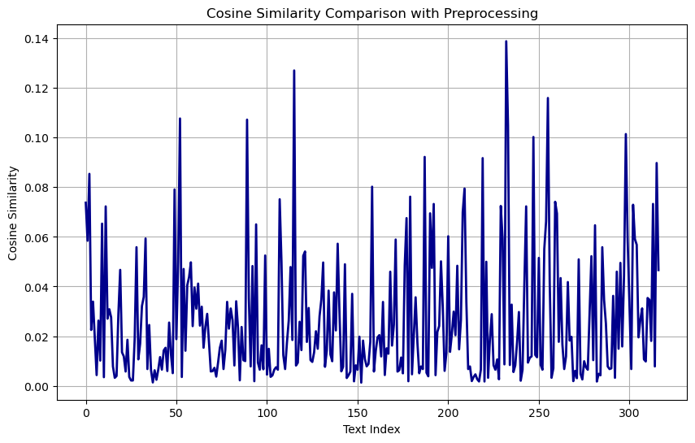

```python
# Plotting the cosine similarity chart
plt.figure(figsize=(10, 6))
plt.plot(range(len(cosine_similarities)), cosine_similarities, color='darkblue', linewidth=2)
plt.title('Cosine Similarity Comparison with Preprocessing')
plt.xlabel('Text Index')
plt.ylabel('Cosine Similarity')
plt.grid(True)
plt.show()
```

### *Lemmatizing*

```python
# Defining a function to lemmatize the texts
def lemmatize_texts(texts):
    # Defining the lemmatizer function
    lemmatizer = WordNetLemmatizer()

    # Initializing a list for the lemmatized texts
    lemmatized_texts = []

    for text in texts:
        # Tokenizing the text into words
        words = text.split()
        # Lemmatizing each word
        lemmatized_words = [lemmatizer.lemmatize(word) for word in words]
        # Joining the lemmatized words back into a single string
        lemmatized_text = ' '.join(lemmatized_words)
        # Appending the words to the list
        lemmatized_texts.append(lemmatized_text)

    return lemmatized_texts

# Lemmatizing the preprocessed texts
lemmatized_texts = lemmatize_texts(preprocessed_texts)

# Fitting and transforming the lemmatized texts
tfidf_matrix_lem = tfidf_vectorizer.fit_transform(lemmatized_texts)

# Calculating the cosine similarity scores
cosine_similarities_lem = cosine_similarity_comparison(tfidf_matrix_lem)
print("Cosine similarities:", cosine_similarities_lem)
```

```
Cosine similarities: [0.08330503 0.05993561 0.09272107 0.03119985 0.04359162 0.0232592
 0.00433167 0.02977408 0.00958366 0.07256254 0.00341636 0.09108118
 0.03110615 0.03591426 0.03153945 0.00765237 0.00315938 0.00386811
 0.03790196 0.05621858 0.05292986 0.02891858 0.00571337 0.04226577
 0.00355975 0.00211269 0.00212639 0.02334671 0.05487189 0.01044528
 0.01691526 0.03282203 0.04729608 0.06858088 0.0066316  0.02393471
 0.00619738 0.00277316 0.00613909 0.00240135 0.00636898 0.01253832
 0.00639013 0.01523856 0.02282513 0.01108063 0.02521495 0.02341256
 0.00499627 0.09072662 0.03264493 0.0531935  0.11157034 0.00349265
 0.0478039  0.01623849 0.0434215  0.04259039 0.05873527 0.03143292
 0.0452131  0.03610324 0.04188891 0.02651057 0.03346183 0.01504272
 0.02634501 0.03372629 0.0206174  0.00638393 0.00582176 0.00868783
 0.00364086 0.01071903 0.01504272 0.02237766 0.0066316  0.02838994
 0.03997213 0.03832763 0.03964273 0.02632631 0.00803226 0.03726101
 0.02293257 0.00213486 0.0258212  0.01595984 0.01607247 0.1192578
 0.04132401 0.00765237 0.04927916 0.00181743 0.06680198 0.01294496
 0.00836461 0.01557759 0.00925909 0.05275428 0.00441663 0.01555848
 0.0056354  0.0041174  0.00635108 0.00735092 0.00636898 0.08259836
 0.0549551  0.01548136 0.0066316  0.01589339 0.02555477 0.04565269
 0.03296356 0.12788966 0.01435668 0.00901554 0.03516934 0.01570033
 0.06417485 0.06143379 0.01932652 0.03070408 0.01015745 0.01750973
 0.03069243 0.02097581 0.01350971 0.02778182 0.03573562 0.04792196
 0.00676853 0.01638573 0.04301277 0.01252867 0.01373147 0.03813487
 0.02481357 0.05821528 0.03145363 0.00742374 0.01487546 0.06068211
 0.00309714 0.00403278 0.00571337 0.04768032 0.00180146 0.00811771
 0.00636898 0.0310742  0.0012662  0.05148764 0.03958165 0.03044041
 0.00987569 0.01929666 0.09175763 0.00571337 0.01489948 0.02085386
 0.0200457  0.01141693 0.03384537 0.00867771 0.01475011 0.02172119
 0.04485196 0.0234688  0.0245721  0.06549387 0.00797226 0.00868133
 0.02075055 0.00492527 0.04547813 0.07310471 0.00374524 0.09093629
 0.00458322 0.02368212 0.03707579 0.01822217 0.00668061 0.00765237
 0.0066316  0.1063673  0.00792263 0.00390514 0.07150226 0.05874877
 0.07860764 0.00421375 0.02333107 0.03081372 0.05823576 0.04456451
 0.00599342 0.01564998 0.07076904 0.0213381  0.02070386 0.03168393
 0.02386439 0.05284331 0.01629844 0.02715174 0.08264012 0.08285918
 0.04361579 0.0066316  0.00765237 0.00188907 0.00349145 0.00545113
 0.00261698 0.00172058 0.00636898 0.09724169 0.00182489 0.05354755
 0.00315938 0.01819877 0.04074681 0.00819147 0.00636898 0.01044128
 0.0025925  0.0780353  0.0739205  0.00884249 0.13794511 0.11545511
 0.00827376 0.03593548 0.00549572 0.01696704 0.02709317 0.03446158
 0.0020172  0.00636898 0.05404119 0.07981267 0.00936605 0.01108299
 0.01119554 0.11169499 0.01221013 0.01112983 0.05835248 0.00827416
 0.00636898 0.05901885 0.07822277 0.13164458 0.05689807 0.00315938
 0.02722672 0.07829393 0.07145174 0.0187825  0.04500192 0.01932963
 0.0066316  0.03371892 0.05923456 0.05148764 0.02415249 0.00186566
 0.00599342 0.00302242 0.05488413 0.00557928 0.00252492 0.00991316
 0.00735092 0.00636898 0.02986511 0.05546206 0.01433139 0.0695074
 0.0052158  0.00488226 0.00848865 0.05504744 0.03775991 0.02573298
 0.00765237 0.0066316  0.00689577 0.03709323 0.00321131 0.05192138
 0.01712853 0.05339776 0.01917189 0.04746623 0.12090473 0.0705433
 0.04082195 0.0066316  0.08002326 0.06388283 0.05477114 0.02478998
 0.03066601 0.03647634 0.01171977 0.01965405 0.0468476  0.04185125
 0.02795347 0.07979617 0.00765237 0.09451531 0.0485872 ]
```

```python
# Finding the index of the most similar text and its cosine similarity score
max_similarity_index_2 = cosine_similarities_lem.argmax()
max_similarity_score_2 = cosine_similarities_lem.max()

# Appending the index and the score to the df
new_result_2 = pd.DataFrame({'Text Index': [max_similarity_index_2 + 1],
                             'Cosine Similarity': [max_similarity_score_2]})
results_df = pd.concat([results_df, new_result_2], ignore_index=True)
```

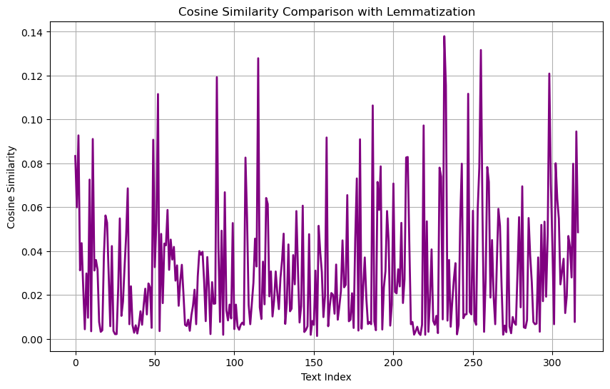

```python
# Plotting the lemmatized cosine similarity scores
plt.figure(figsize=(10, 6))
plt.plot(range(len(cosine_similarities_lem)), cosine_similarities_lem, color='purple', linewidth=2)
plt.title('Cosine Similarity Comparison with Lemmatization')
plt.xlabel('Text Index')
plt.ylabel('Cosine Similarity')
plt.grid(True)
plt.show()
```

### *Stemming*

```python
# Defining a function to stemm the speeches
def perform_stemming(texts):
    # Initializing the stemmer
    stemmer = LancasterStemmer()

    # Performing stemming on each text in the list
    stemmed_texts = []

    for text in texts:
        # Splitting the text
        words = text.split()
        # Stemming each word
        stemmed_words = [stemmer.stem(word) for word in words]
        # Joining the stemmed words into a single string
        stemmed_text = ' '.join(stemmed_words)
        # Appending them to the list
        stemmed_texts.append(stemmed_text)

    return stemmed_texts

# Applying the stemmer to the preprocessed_texts
stemmed_texts = perform_stemming(preprocessed_texts)

# Fitting and transforming the stemmed texts
tfidf_matrix_stem = tfidf_vectorizer.fit_transform(stemmed_texts)

# Calculating the cosine similarity scores
cosine_similarities_stem = cosine_similarity_comparison(tfidf_matrix_stem)
print("Cosine similarities:", cosine_similarities_stem)
```

```
Cosine similarities: [0.11477345 0.07356922 0.12783454 0.05527066 0.04885283 0.02277129
 0.00855414 0.03748736 0.01264905 0.0911589  0.00593667 0.11285161
 0.04770438 0.06301459 0.04076685 0.00774966 0.00322284 0.00476006
 0.04359349 0.08189397 0.05443436 0.02894192 0.01065    0.04459647
 0.01264675 0.00338746 0.00544923 0.03202876 0.07252538 0.01043029
 0.02790711 0.04828833 0.06051424 0.10147987 0.00673183 0.05075166
 0.01033373 0.01894287 0.00892724 0.00918588 0.00665352 0.0243868
 0.00933425 0.02817612 0.02318211 0.01517104 0.03252829 0.02392421
 0.00518367 0.10925052 0.05408732 0.07751997 0.13638135 0.00650409
 0.06381647 0.02553985 0.05696645 0.05129734 0.06699641 0.0548488
 0.05998045 0.0547535  0.07018883 0.03388199 0.03357907 0.01510322
 0.03509753 0.04200889 0.033156   0.00543752 0.00842034 0.02246533
 0.00636073 0.02451158 0.01510322 0.02854709 0.00673183 0.03008857
 0.04728747 0.05337034 0.06959779 0.04304265 0.0080877  0.06891521
 0.04454428 0.00652203 0.03687645 0.0192757  0.02506519 0.1356178
 0.05885735 0.00774966 0.05786644 0.00184922 0.1061412  0.01563598
 0.00866018 0.02642675 0.01078542 0.07662163 0.00443427 0.01705931
 0.00982132 0.00452281 0.00643605 0.0075203  0.00665352 0.11103862
 0.07228545 0.01611546 0.00673183 0.01745033 0.03364389 0.05777447
 0.03792009 0.13290546 0.03090501 0.01122673 0.03727303 0.02336691
 0.07884173 0.10581971 0.03408044 0.03032726 0.01354489 0.03456667
 0.03494058 0.02930299 0.02699611 0.03256089 0.03945613 0.04204043
 0.03090446 0.02720993 0.05724887 0.01703632 0.01563598 0.04619281
 0.03702169 0.07362501 0.04151656 0.00780087 0.03240051 0.07034196
 0.00542912 0.0108172  0.01065    0.06326774 0.02834555 0.00800337
 0.00665352 0.03664464 0.00129489 0.05166139 0.04026393 0.0329402
 0.01338516 0.03308194 0.11925602 0.01065    0.03406764 0.02400272
 0.0254503  0.02271038 0.03826631 0.01044002 0.03004098 0.02610153
 0.04451325 0.02767216 0.02794859 0.07683058 0.00832075 0.0087693
 0.02395941 0.00496145 0.05515593 0.09891221 0.03261577 0.13008578
 0.00475504 0.02697525 0.04388627 0.0316966  0.00576647 0.00774966
 0.00673183 0.1214244  0.00999935 0.00400282 0.09444307 0.06807251
 0.11247732 0.00617588 0.02613501 0.04149904 0.08538162 0.06081422
 0.01093566 0.01951538 0.08270306 0.02334371 0.04125059 0.04843594
 0.03043924 0.09542307 0.02541442 0.04113884 0.11416267 0.11364659
 0.08237412 0.00673183 0.00774966 0.00343809 0.00351888 0.0054953
 0.00266829 0.01719442 0.00665352 0.12843178 0.00328058 0.08452053
 0.00322284 0.02597644 0.04921782 0.01064413 0.00665352 0.01102006
 0.00447555 0.09809937 0.09498323 0.01082944 0.14659361 0.12038121
 0.00850043 0.06337039 0.00880787 0.01698517 0.04332898 0.05274476
 0.00202966 0.00665352 0.07093069 0.09165532 0.00822183 0.03665939
 0.01110269 0.11531822 0.01219529 0.03835393 0.08165389 0.01326006
 0.00665352 0.07436449 0.09037107 0.13646993 0.09833116 0.00322284
 0.02835764 0.09462482 0.09439557 0.03632802 0.06431273 0.02348174
 0.00673183 0.03613731 0.07855897 0.05166139 0.0321984  0.00666562
 0.01093566 0.00311747 0.0889879  0.00545653 0.00357288 0.01025467
 0.0075203  0.00665352 0.03616897 0.08406252 0.01428347 0.07571853
 0.00661195 0.01825707 0.00995779 0.08170183 0.05580719 0.02861869
 0.00774966 0.00673183 0.01530301 0.04425932 0.01789504 0.07743944
 0.03713012 0.07993119 0.02974999 0.05872336 0.13704676 0.08225048
 0.0495453  0.00673183 0.10660267 0.08462122 0.06417363 0.03633729
 0.05140164 0.04290619 0.01426284 0.02641087 0.04918905 0.05555942
 0.04374259 0.11727413 0.00774966 0.12827688 0.06358862]
```

```python
# Finding the index of the most similar text and its cosine similarity score
max_similarity_index_3 = cosine_similarities_stem.argmax()
max_similarity_score_3 = cosine_similarities_stem.max()

# Appending the index and the score
new_result_3 = pd.DataFrame({'Text Index': [max_similarity_index_3 + 1],
                             'Cosine Similarity': [max_similarity_score_3]})
results_df = pd.concat([results_df, new_result_3], ignore_index=True)
```

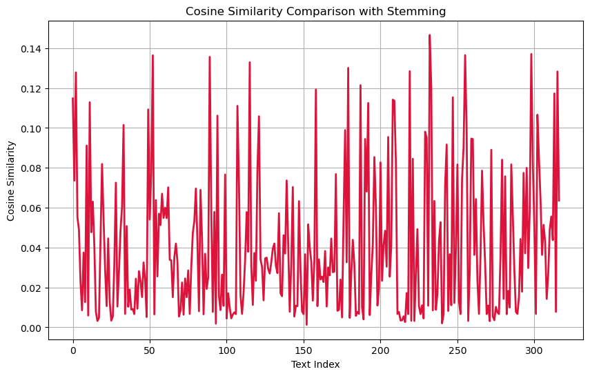

```python
# Plotting the chart for stemming
plt.figure(figsize=(10, 6))
plt.plot(range(len(cosine_similarities_stem)), cosine_similarities_stem, color='crimson', linewidth=2)
plt.title('Cosine Similarity Comparison with Stemming')
plt.xlabel('Text Index')
plt.ylabel('Cosine Similarity')
plt.grid(True)
plt.show()
```

## *Bonus: Adding the stopwords from droplist.txt*

```python
# Importing the droplist.txt from GitHub
url = "https://raw.githubusercontent.com/ariedamuco/Python-Programming-and-Text-Analysis/master/Inputs/droplist.txt"

# Fetching the content from the url and saving it as content
response = requests.get(url)
content = response.text

# Extracting words between hyphens using regular expression
drop_words = re.findall(r'"(.*?)"', content)

# Appending each additional stop word to scikit's stop_words list
for word in drop_words:
    stop_words.append(word)
```

```python
# The number of stop_words, including the droplist.txt words
len(stop_words)
```

```
1030
```

### *Cosine similarity with preprocessing only*

```python
# Defining the preprocess_text function to clean the speeches
def preprocess_texts(texts, stop_words):
    preprocessed_texts = []
    for text in texts:
        # Converting text to lowercase
        text_lower = text.lower()
        # Removing punctuations
        text_no_punctuation = text_lower.translate(str.maketrans('', '', string.punctuation))
        # Tokenizing the text into words
        words = text_no_punctuation.split()
        # Removing the stop words
        filtered_words = [word for word in words if word not in stop_words]
        # Joining the filtered words
        preprocessed_text = ' '.join(filtered_words)
        # Appending the preprocessed text to the list
        preprocessed_texts.append(preprocessed_text)

    return preprocessed_texts

# Preprocessing the texts in extracted_strings
preprocessed_texts = preprocess_texts(extracted_strings, stop_words)

# Fitting and transforming
tfidf_matrix_droplist = tfidf_vectorizer.fit_transform(preprocessed_texts)

# Calculating the cosine similarity scores
cosine_similarities_droplist = cosine_similarity_comparison(tfidf_matrix_droplist)
print("Cosine similarities:", cosine_similarities_droplist)
```

```
Cosine similarities: [0.07082384 0.0541111  0.07095218 0.02240547 0.03102464 0.01726556
 0.         0.02074514 0.         0.04205683 0.         0.07319718
 0.02302657 0.0184012  0.02105585 0.00263094 0.         0.
 0.02784921 0.02396516 0.01381633 0.00836339 0.         0.0193034
 0.00132352 0.00130374 0.         0.01411804 0.04665422 0.00492985
 0.01641252 0.03209944 0.02238557 0.04691173 0.00254895 0.01946308
 0.00394176 0.         0.0034845  0.         0.00222614 0.01068764
 0.0036367  0.01244665 0.01433743 0.0048036  0.02616811 0.01351603
 0.         0.07308105 0.01044724 0.04224768 0.10001239 0.
 0.04187866 0.00799305 0.02554813 0.03254347 0.0446873  0.02447087
 0.02875912 0.0197116  0.0344615  0.01631963 0.01520917 0.0063537
 0.02190333 0.02142973 0.00791103 0.00335322 0.00329381 0.00619989
 0.00208729 0.00733645 0.0063537  0.01779917 0.00254895 0.01183841
 0.02839412 0.02105811 0.02369908 0.02026943 0.         0.03036617
 0.02256782 0.00074751 0.01588827 0.00037618 0.0040411  0.10814421
 0.02759367 0.00263094 0.03979424 0.         0.05875636 0.00323612
 0.00193712 0.00136677 0.00220876 0.03963612 0.         0.00111603
 0.         0.         0.00221892 0.00250913 0.00222614 0.06776208
 0.04733393 0.00126549 0.00254895 0.0162244  0.02483679 0.0477062
 0.00944167 0.12829705 0.00727841 0.00755437 0.02529003 0.00952528
 0.0448381  0.05044767 0.01394549 0.0301864  0.00892565 0.00739186
 0.01135583 0.02025656 0.01384638 0.026859   0.03254937 0.04916572
 0.00598595 0.00949929 0.01554136 0.00474399 0.00346868 0.01604242
 0.01489096 0.04623007 0.01319635 0.0045432  0.00683665 0.03704559
 0.         0.         0.         0.02835757 0.         0.00174682
 0.00222614 0.01109305 0.         0.01218557 0.00658012 0.00532058
 0.000395   0.01361962 0.06581119 0.         0.01217809 0.01345849
 0.01934586 0.01021216 0.03253517 0.0027619  0.0142073  0.01159105
 0.045284   0.01552637 0.02300052 0.04698682 0.00188174 0.00207815
 0.00978048 0.         0.04108726 0.06482804 0.         0.05943947
 0.00220558 0.00524612 0.01421445 0.01558964 0.00381345 0.00263094
 0.00254895 0.09698882 0.00194258 0.         0.06736544 0.03771288
 0.06131572 0.         0.00661924 0.02411404 0.04752178 0.02694556
 0.         0.00711111 0.04688711 0.01385964 0.01744664 0.0252551
 0.01726283 0.04181541 0.01287135 0.01880228 0.0650223  0.07677504
 0.03012169 0.00254895 0.00263094 0.         0.         0.
 0.         0.         0.00222614 0.0893593  0.         0.04218162
 0.         0.01525289 0.02190222 0.0028175  0.00222614 0.00917808
 0.         0.06895082 0.04887772 0.00295215 0.14044491 0.10524083
 0.00694769 0.02388182 0.00331114 0.         0.00456453 0.02745445
 0.         0.00222614 0.03479712 0.06396941 0.00732404 0.01102473
 0.         0.09678201 0.00464186 0.00165961 0.04662287 0.00183665
 0.00222614 0.04895726 0.06486895 0.11067959 0.03866195 0.
 0.00653196 0.07048327 0.06862318 0.01429825 0.04107124 0.00981692
 0.00254895 0.00739119 0.03986848 0.01218557 0.01584866 0.
 0.         0.         0.04816899 0.00373419 0.00119712 0.00431109
 0.00250913 0.00222614 0.02735717 0.04669071 0.00365119 0.04980161
 0.         0.         0.         0.05744839 0.02468208 0.01852434
 0.00263094 0.00254895 0.00394483 0.02268025 0.00106923 0.04242219
 0.00830561 0.04024254 0.00920633 0.03803596 0.09560347 0.04925144
 0.02864515 0.00254895 0.06655211 0.05775674 0.05249372 0.00314139
 0.01620645 0.02797541 0.00770785 0.00404957 0.00963556 0.02192025
 0.01713878 0.06741217 0.00263094 0.0825751  0.04311899]
```

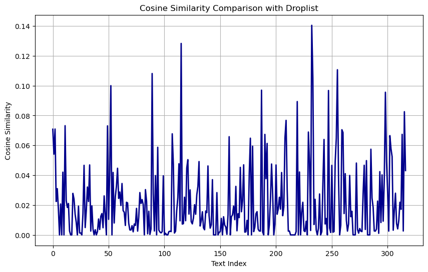

```python
# Plotting the preprocessed text with the droplist
plt.figure(figsize=(10, 6))
plt.plot(range(len(cosine_similarities_droplist)), cosine_similarities_droplist, color='darkblue', linewidth=2)
plt.title('Cosine Similarity Comparison with Droplist')
plt.xlabel('Text Index')
plt.ylabel('Cosine Similarity')
plt.grid(True)
plt.show()
```

```python
# Finding the index of the most similar text and its cosine similarity score
max_similarity_index_4 = cosine_similarities_droplist.argmax()
max_similarity_score_4 = cosine_similarities_droplist.max()

# Appending the index and the score
new_result_4 = pd.DataFrame({'Text Index': [max_similarity_index_4 + 1],
                             'Cosine Similarity': [max_similarity_score_4]})
results_df = pd.concat([results_df, new_result_4], ignore_index=True)
```

### *Lemmatizing with the droplist*

```python
# Lemmatizing the preprocessed texts
lemmatized_texts = lemmatize_texts(preprocessed_texts)

# Fitting and transforming the lemmatized texts
tfidf_matrix_droplist_lem = tfidf_vectorizer.fit_transform(lemmatized_texts)

# Calculating cosine similarity scores
cosine_similarities_droplist_lem = cosine_similarity_comparison(tfidf_matrix_droplist_lem)
print("Cosine similarities:", cosine_similarities_droplist_lem)
```

```
Cosine similarities: [0.08101946 0.05452612 0.07514554 0.03139759 0.03915433 0.01926191
 0.         0.02450252 0.         0.04704402 0.         0.09310672
 0.02735241 0.02005842 0.02559541 0.00258272 0.         0.
 0.03857583 0.03147732 0.07951951 0.02630509 0.         0.04795052
 0.0013265  0.00128045 0.         0.01815659 0.04522634 0.0048395
 0.01638711 0.03295604 0.03008325 0.05557453 0.00250224 0.01922192
 0.00387546 0.00145335 0.00342064 0.         0.00218996 0.01169423
 0.00357004 0.01352889 0.02222835 0.01010284 0.02591911 0.02608074
 0.         0.08407914 0.01537975 0.04406728 0.10268915 0.
 0.04279239 0.00809149 0.02579711 0.03185568 0.05395091 0.0322811
 0.03149173 0.02063105 0.03303547 0.01739531 0.01678399 0.00623726
 0.02451924 0.02608001 0.00752991 0.00376928 0.00323344 0.00773028
 0.00204903 0.00886445 0.00623726 0.02205229 0.00250224 0.02623101
 0.03296637 0.03703649 0.03072017 0.01902158 0.         0.03338231
 0.02219834 0.00072089 0.01705385 0.00037368 0.00673988 0.11928558
 0.03185961 0.00258272 0.03965179 0.         0.060131   0.00731999
 0.00436247 0.00134708 0.00501896 0.04084062 0.         0.00209664
 0.00217877 0.         0.00218282 0.00246977 0.00218996 0.07241962
 0.05265567 0.00457653 0.00250224 0.0146828  0.02414259 0.04180848
 0.01948731 0.12683402 0.01399683 0.00729475 0.03270218 0.00880669
 0.05375061 0.05612389 0.01584446 0.02957637 0.00873879 0.01422924
 0.02836312 0.01927334 0.01238141 0.02660681 0.03146579 0.04742569
 0.00509655 0.01007144 0.01757644 0.00472166 0.0078541  0.01551944
 0.01464682 0.04661315 0.01280166 0.00627953 0.01430635 0.04600016
 0.         0.         0.         0.03916842 0.         0.00172378
 0.00218996 0.01907132 0.         0.05054793 0.03753384 0.03002356
 0.00074224 0.01450622 0.07503195 0.         0.01129766 0.01222152
 0.01887232 0.00982829 0.03264394 0.00732742 0.01386989 0.02099647
 0.04421743 0.02338894 0.02303292 0.04806964 0.00427472 0.0046818
 0.01969802 0.         0.0380335  0.06779845 0.00222891 0.06971126
 0.00218287 0.00655209 0.01619424 0.01664329 0.00558558 0.00258272
 0.00250224 0.11094708 0.00491583 0.         0.06905057 0.04768305
 0.06561485 0.         0.0064936  0.03112651 0.05637356 0.03769248
 0.         0.01068005 0.05406691 0.02211517 0.0166337  0.02700976
 0.02030844 0.04527373 0.01401575 0.01882052 0.07840221 0.07964657
 0.04004429 0.00250224 0.00258272 0.         0.         0.
 0.         0.         0.00218996 0.09465883 0.         0.04541208
 0.         0.0151248  0.0311506  0.00278873 0.00218996 0.00902126
 0.         0.0726887  0.06337223 0.00304513 0.13972885 0.1166639
 0.00686425 0.02508318 0.00334011 0.01068494 0.0148048  0.03125345
 0.         0.00218996 0.0481022  0.06900279 0.00734203 0.01084883
 0.         0.10894456 0.00455679 0.00165967 0.0526654  0.00180558
 0.00218996 0.05240752 0.07813477 0.12638377 0.05564839 0.
 0.02962579 0.07408072 0.07017136 0.01409271 0.04231738 0.00928728
 0.00250224 0.0308021  0.0565209  0.05054793 0.01979175 0.
 0.         0.         0.04941594 0.00454653 0.00118289 0.00437771
 0.00246977 0.00218996 0.02796381 0.04861414 0.00827444 0.05080623
 0.00370737 0.         0.00457682 0.05706613 0.02694405 0.01858063
 0.00258272 0.00250224 0.00387477 0.02212472 0.0010671  0.04838741
 0.00976259 0.04044693 0.00920992 0.03821859 0.11325375 0.05758313
 0.03538676 0.00250224 0.07294869 0.06112247 0.05049463 0.00540292
 0.01945635 0.03132651 0.00911944 0.01301726 0.01443452 0.02789461
 0.02565369 0.07391134 0.00258272 0.08480771 0.04483896]
```

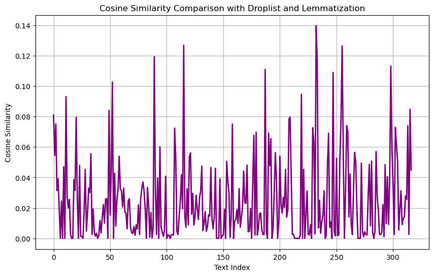

```python
# Plotting the cosine similarities with the droplist and lemmatization
plt.figure(figsize=(10, 6))
plt.plot(range(len(cosine_similarities_droplist_lem)), cosine_similarities_droplist_lem, color='purple', linewidth=2)
plt.title('Cosine Similarity Comparison with Droplist and Lemmatization')
plt.xlabel('Text Index')
plt.ylabel('Cosine Similarity')
plt.grid(True)
plt.show()
```

```python
# Finding the index of the most similar text and its cosine similarity score
max_similarity_index_5 = cosine_similarities_droplist_lem.argmax()
max_similarity_score_5 = cosine_similarities_droplist_lem.max()

# Appending the index and the score
new_result_5 = pd.DataFrame({'Text Index': [max_similarity_index_5 + 1],
                             'Cosine Similarity': [max_similarity_score_5]})
results_df = pd.concat([results_df, new_result_5], ignore_index=True)
```

### *Stemming with Droplist*

```python
# Stemming the preprocessed text
stemmed_texts = perform_stemming(preprocessed_texts)

# Fitting and transforming
tfidf_matrix_droplist_stem = tfidf_vectorizer.fit_transform(stemmed_texts)

# Calculating the cosine similarity scores
cosine_similarities_droplist_stem = cosine_similarity_comparison(tfidf_matrix_droplist_stem)
print("Cosine similarities:", cosine_similarities_droplist_stem)
```

```
Cosine similarities: [0.11292147 0.06890969 0.10689411 0.05498909 0.04462529 0.0177497
 0.00365771 0.03196642 0.00311169 0.06539361 0.00507436 0.11582812
 0.04407016 0.04645956 0.03466137 0.00258328 0.         0.
 0.04173627 0.05757379 0.07976947 0.02620346 0.00491152 0.05101915
 0.00264267 0.00263245 0.00394164 0.02717114 0.06419261 0.00476771
 0.02752924 0.04946052 0.04217277 0.08339816 0.00249132 0.03517528
 0.0086323  0.00505977 0.00618842 0.00925569 0.00226738 0.01264179
 0.0064915  0.01471222 0.0225302  0.0142329  0.03353893 0.0263895
 0.         0.10134567 0.03179205 0.06740428 0.12524213 0.00491152
 0.05860486 0.01723402 0.03854295 0.04263991 0.06034431 0.05011752
 0.04609354 0.03807316 0.06217514 0.02377584 0.0195972  0.00620019
 0.03376717 0.0346383  0.01921387 0.00245487 0.00581492 0.00841518
 0.00478148 0.00962963 0.00620019 0.02833543 0.00249132 0.02769846
 0.04040065 0.052739   0.05856713 0.03638345 0.         0.06164398
 0.04402963 0.00534926 0.02633585 0.00312373 0.01529039 0.13473435
 0.04733386 0.00258328 0.04852904 0.         0.09985901 0.00915699
 0.00455158 0.01337886 0.00588299 0.06787155 0.         0.00270908
 0.00605024 0.         0.00218122 0.00249797 0.00226738 0.10108912
 0.07081968 0.00514145 0.00249132 0.01593221 0.0324598  0.05447284
 0.02409658 0.13181782 0.03204241 0.00946038 0.03474275 0.01660409
 0.06831315 0.0999759  0.03281125 0.02905822 0.01226477 0.03269785
 0.03293338 0.02766287 0.01682375 0.03144394 0.03488175 0.0412117
 0.02989063 0.02096968 0.03059609 0.00964653 0.00915699 0.022849
 0.0246837  0.06087698 0.02402892 0.00658027 0.03225644 0.05445349
 0.0025849  0.00797268 0.00491152 0.05720961 0.01029879 0.001703
 0.00226738 0.02478249 0.         0.05067358 0.03825765 0.03273246
 0.00274443 0.02877023 0.09886153 0.00491152 0.02957088 0.0150949
 0.02446196 0.02137289 0.03713968 0.00911393 0.02975068 0.02564256
 0.04377489 0.02794135 0.02645867 0.05863544 0.00443201 0.00468868
 0.02257441 0.         0.04781938 0.09278897 0.01532496 0.11114732
 0.00224348 0.00668426 0.02318432 0.02982841 0.0045921  0.00258328
 0.00249132 0.12656176 0.0073213  0.         0.09318235 0.0579489
 0.10121375 0.00289551 0.008217   0.04033812 0.08520893 0.05069974
 0.00507436 0.01187805 0.06370986 0.0241913  0.03582499 0.04421618
 0.02354178 0.08183581 0.02025421 0.03258301 0.11085786 0.11031703
 0.07680571 0.00249132 0.00258328 0.00170731 0.         0.
 0.         0.01398587 0.00226738 0.12568035 0.00143685 0.07634809
 0.         0.01636845 0.0380968  0.00530389 0.00226738 0.00948607
 0.00247737 0.09004416 0.07808528 0.00383943 0.14774326 0.12183432
 0.00693579 0.05057755 0.01058027 0.01062665 0.03110006 0.04741305
 0.         0.00226738 0.06578608 0.08017972 0.00602152 0.04251332
 0.         0.1125937  0.00448855 0.00924819 0.07330552 0.00682157
 0.00226738 0.06737742 0.09151406 0.13160311 0.09956975 0.
 0.03094296 0.08926206 0.08973733 0.03036881 0.06112028 0.0127334
 0.00249132 0.03321535 0.07250825 0.05067358 0.02295808 0.00622338
 0.00507436 0.         0.08562015 0.00438839 0.00224535 0.00448855
 0.00249797 0.00226738 0.03459941 0.07716058 0.00817022 0.05740989
 0.00510604 0.01279142 0.00541358 0.0869531  0.04305197 0.01980205
 0.00258328 0.00249132 0.0124805  0.03012089 0.00439827 0.07463868
 0.0302236  0.06659622 0.01857376 0.05072775 0.1288356  0.06899604
 0.04382981 0.00249132 0.09893315 0.08238943 0.06018827 0.01756905
 0.0402528  0.03650175 0.01179207 0.02060508 0.01525485 0.04241578
 0.03916685 0.11104586 0.00258328 0.11578917 0.05873179]
```

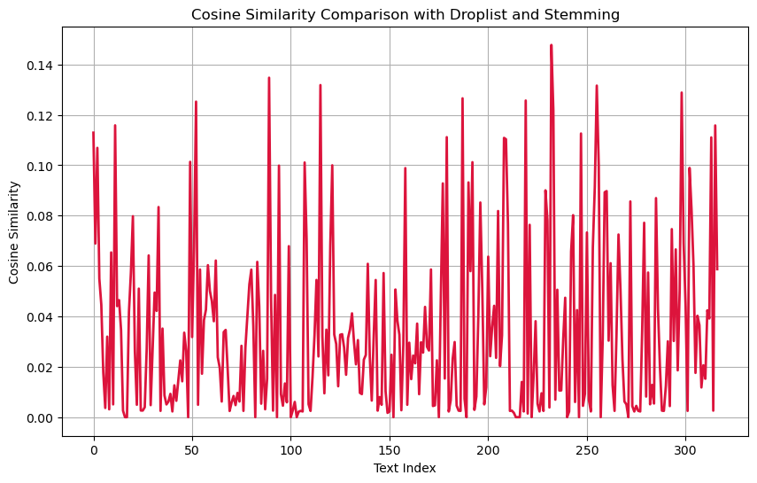

```python
# Plotting the final cosine similarity chart with stemming
plt.figure(figsize=(10, 6))
plt.plot(range(len(cosine_similarities_droplist_stem)), cosine_similarities_droplist_stem, color='crimson', linewidth=2)
plt.title('Cosine Similarity Comparison with Droplist and Stemming')
plt.xlabel('Text Index')
plt.ylabel('Cosine Similarity')
plt.grid(True)
plt.show()
```

```python
# Finding the index of the most similar text and its cosine similarity score
max_similarity_index_6 = cosine_similarities_droplist_stem.argmax()
max_similarity_score_6 = cosine_similarities_droplist_stem.max()

# Appending the index and the score
new_result_6 = pd.DataFrame({'Text Index': [max_similarity_index_6 + 1],
                             'Cosine Similarity': [max_similarity_score_6]})
results_df = pd.concat([results_df, new_result_6], ignore_index=True)
```

```python
# Defining the row names
process_names = ["Preprocessed without Droplist, Lem and Stem",
                 "Processed with Lem",
                 "Preprocessed with Stem",
                 "Preprocessed with Droplist",
                 "Preprocessed with Droplist and Lem",
                 "Preprocessed with Droplist and Stem"]

# Adding the row names as indexes to the results_df
results_df.index = process_names
results_df
```

|  | Text Index | Cosine Similarity |
| --- | --- | --- |
| Preprocessed without Droplist, Lem and Stem | 233 | 0.138801 |
| Processed with Lem | 233 | 0.137945 |
| Preprocessed with Stem | 233 | 0.146594 |
| Preprocessed with Droplist | 233 | 0.140445 |
| Preprocessed with Droplist and Lem | 233 | 0.139729 |
| Preprocessed with Droplist and Stem | 233 | 0.147743 |

```python
# Checking the stemmed text with the highest cosine similarity
stemmed_texts[233]
```

```
'madam presid thank 1994 op lend auth ins fin rais froz tim admin'
```

```python
# Creating a dictionary for the cosine similarity scores DataFrame
cosine_similarity_arrays = {
    'cosine_similarities': cosine_similarities,
    'cosine_similarities_lem': cosine_similarities_lem,
    'cosine_similarities_stem': cosine_similarities_stem,
    'cosine_similarities_droplist': cosine_similarities_droplist,
    'cosine_similarities_droplist_lem': cosine_similarities_droplist_lem,
    'cosine_similarities_droplist_stem': cosine_similarities_droplist_stem
}

cosine_similarities_descriptions_df = pd.DataFrame()

# Looping through each key-value pair and appending the descriptions
for key, value in cosine_similarity_arrays.items():
    cosine_similarities_descriptions_df[key] = pd.Series(value).describe()

# Calling the DataFrame
cosine_similarities_descriptions_df
```

|  | cosine_similarities | cosine_similarities_lem | cosine_similarities_stem | cosine_similarities_droplist | cosine_similarities_droplist_lem | cosine_similarities_droplist_stem |
| --- | --- | --- | --- | --- | --- | --- |
| count | 317.000000 | 317.000000 | 317.000000 | 317.000000 | 317.000000 | 317.000000 |
| mean | 0.026491 | 0.030507 | 0.040535 | 0.021366 | 0.024977 | 0.034268 |
| std | 0.025691 | 0.028082 | 0.034898 | 0.025303 | 0.027558 | 0.034193 |
| min | 0.001284 | 0.001266 | 0.001295 | 0.000000 | 0.000000 | 0.000000 |
| 25% | 0.006755 | 0.007652 | 0.010440 | 0.002549 | 0.002583 | 0.005106 |
| 50% | 0.017311 | 0.022825 | 0.031697 | 0.012447 | 0.016194 | 0.025643 |
| 75% | 0.037635 | 0.045002 | 0.058723 | 0.030366 | 0.038219 | 0.050700 |
| max | 0.138801 | 0.137945 | 0.146594 | 0.140445 | 0.139729 | 0.147743 |

## Interpreting the results

Wayne Allard (born in 1942) is an American veterinarian and politican who served as a United States Representative and United States Senator from Colorado. He was a member of the Republican party but he is no longer active as a Senator.

In the first speech of the attached document, Mr. Allard discussed the Auto Choice Reform Act, proposing a 'no fault compensation system' to alleviate the financial burden on drivers, particularly low-income and urban ones, while highlighting potential cost savings for both individuals and businesses.

We can observe that Mr. Allard's 232nd speech continously exhibits the highest cosine similarity with his first speech, namely:

*Mr. ALLARD. Madam President, I thank you. In 1994, OPIC's lending authority for its insurance financing was last raised and has been frozen ever since. Since that time, the administration----*

It is really interesting to compare the content of the first speech to the most similar one, as they don't share much resemblance. Potentially, the word *insurance* contributes to the high similarity score which appears 14 times in Mr. Allard's first speech.

| Process Name | Text Index | Cosine Similarity |
| --- | --- | --- |
| Preprocessed without Droplist, Lem and Stem | 233 | 0.138801 |
| Processed with Lem | 233 | 0.137945 |
| Preprocessed with Stem | 233 | 0.146594 |
| Preprocessed with Droplist | 233 | 0.140445 |
| Preprocessed with Droplist and Lem | 233 | 0.139729 |
| Preprocessed with Droplist and Stem | 233 | 0.147743 |

### Cosine Similarity Scores

Interestingly, the lowest cosine similarity score didn't belong to the first preprocessed text, where I only transformed the letters to lowercase and removed the punctuations, but to the lemmatized text. This suggest that lemmatization removed or grouped together words that could have been considered distinct in their original form, leading to a decrease in the cosine similarity score. Compared to the lemmatized text, stemming improved the cosine similarity score by almost 1, implying that stemming performed better in terms of preserving the semantic similarity between texts.

By importing the droplist.txt, I added 712 additional stop words. I expected the cosine similarity scores to improve at least by one entire score, however they have not improved as much as I expected them. They performed similar to the preprocessed texts with scikit-learn's stop words. This suggested that the stop words in drop list didn't have a significant impact on improving the semantic similarity inbetween the first and the rest of Mr. Allard's speeches. Similary, lemmatization was the weakest performer (0.1397). However, the lemmatized text still achieved a better score with the droplist stop words than without. Of all the preprocessed texts, steming in conjunction with droplist stop words yielded the highest cosine similarity score, reaching 0.1477.

|  | cosine_similarities | cosine_similarities_lem | cosine_similarities_stem | cosine_similarities_droplist | cosine_similarities_droplist_lem | cosine_similarities_droplist_stem |
| --- | --- | --- | --- | --- | --- | --- |
| count | 317.000000 | 317.000000 | 317.000000 | 317.000000 | 317.000000 | 317.000000 |
| mean | 0.026491 | 0.030507 | 0.040535 | 0.021366 | 0.024977 | 0.034268 |
| std | 0.025691 | 0.028082 | 0.034898 | 0.025303 | 0.027558 | 0.034193 |
| min | 0.001284 | 0.001266 | 0.001295 | 0.000000 | 0.000000 | 0.000000 |
| 25% | 0.006755 | 0.007652 | 0.010440 | 0.002549 | 0.002583 | 0.005106 |
| 50% | 0.017311 | 0.022825 | 0.031697 | 0.012447 | 0.016194 | 0.025643 |
| 75% | 0.037635 | 0.045002 | 0.058723 | 0.030366 | 0.038219 | 0.050700 |
| max | 0.138801 | 0.137945 | 0.146594 | 0.140445 | 0.139729 | 0.147743 |

To get a more detailed overview on cosine similarity scores, I analyzed their metrics with the `.describe()` function. Correspondingly, the stemming process obtains the highest percentile values. The mean and median values of the cosine similarities for the original texts, without any language processing applied, are lower than those for the stemmed and lemmatized versions.

Out of curiousity, I checked the stemmed text with the highest cosine similarity score:

*madam presid thank 1994 op lend auth ins fin rais froz tim admin*

We can see that the stemming sliced off most grammatical endings, only leaving the core of the words. We can say that stop words here were sufficient as all the words, such as *i, you, for, its, was, and, has, been, evern since, the* words were removed. The most definitive word, *insurance* is present as *ins*.

## Evolution and changes over time

I plotted the change of cosine similarity scores for each preprocessed text. Preprocessed texts without text processing techniques are marked with dark blue, lemmatized text scores appear purple and the stemming line chart has a distinctive crimson color. Based on the plots, the cosine similarity scores don't follow a pattern, they are completely independent of each other. There are several texts achieving a 0.13 similarity score, but they span through the entire x axis. There is a cluster of highly similar texts around the index 233, suggesting that the topic at that time could have been linked to either to the Auto Choice Reform Act or some kind of insurance related legislation.

### Limitations

I initially considered plotting the changes over time by year, only to realize that the years were removed during preprocessing when we extracted the strings between the 'DOC' signs. I believe the dates on the x axis could have gave us more insight in terms of similarity in speeches, maybe further discovering burning topics in certain time periods.